# Notes 1.1-1.4

```python
import numpy as np
import pandas as pd
import matplotlib.pyplot as plt
```

```python
# Helper Functions for 1.1
def prediction(X, W, b):
    '''
    helper function: binary classfication
    '''
    y = (np.matmul(X,W)+b)[0]
    return 1 if y >= 0 else 0


# Helper Functions for 1.2
def plot_points(X, y):
    '''
    Helper funtion: plot the data
    '''
    admitted = X[np.argwhere(y==1)]
    rejected = X[np.argwhere(y==0)]
    plt.scatter([s[0][0] for s in rejected], [s[0][1] for s in rejected], s = 25, color='blue', edgecolor = 'k')
    plt.scatter([s[0][0] for s in admitted], [s[0][1] for s in admitted], s = 25, color='red', edgecolor = 'k')

def display(m, b, color='g--'):
    '''
    Helper function: plot the lines
    '''
    plt.xlim(-0.05, 1.05)
    plt.ylim(-0.05, 1.05)
    x = np.arange(-10, 10, 0.1)
    plt.plot(x, m*x+b, color)

# Helper Functions for 1.3
def one_hot_encoding(data, dummy_list):
    '''
    Do one hot encoding for column x in data
    '''
    for field in dummy_list:
        data = pd.get_dummies(data, columns=[field])
    return data

def one_hot_encoding2(data, dummy_list):
    '''
    Equivalent to one_hot_encoding
    '''
    for field in dummy_list:
        out = pd.concat([data, pd.get_dummies(data[field], prefix=field)], axis=1)
        out = out.drop(x, axis=1)
    return out

def standadize(data, fields):
    for field in fields:
        mean, std = data[field].mean(), data[field].std()
        data.loc[:,field] = (data[field]-mean)/std
    return data

def train_test_split(data, train_ratio):
    sample = np.random.choice(data.index, size=int(len(data)*train_ratio), replace=False)
    train, test = data.iloc[sample], data.drop(sample)
    return train, test

def feature_target_split(data, target):
    features = data.drop(target, axis=1).values
    targets = data[target].values
    return features, targets

# Helper Functions for 1.4
def MSE(y, Y):
    return np.mean((y-Y)**2)
```

## 1.1 Perceptron Algorithm

1. Start with random weights $w_1, ..., w_n, b$
2. For every misclassified pont $x_1, ..., x_n$:  
   2.1. if $\hat{y} < y:$ for $i=1, ..., n: w_i+=\alpha*x_i , b+=\alpha$  
   2.2. if $\hat{y} > y:$ for $i=1, ..., n: w_i-=\alpha*x_i , b-=\alpha$

```python
np.random.seed(12345)

def perceptronStep(X, y, W, b, learn_rate=0.01):
    for i in range(len(X)):
        y_hat = prediction(X[i], W, b)
        Xi = X[i].reshape((2, 1))
        # Here X[i].shape=(2,) while W.shape=(2,1)
        # Alternatively, if not using reshape, then need to do element-wise update
        # update W[0] with X[i][0], W[1] with X[i][1] separately
        if y[i] - y_hat == 1:
            W += Xi * learn_rate
            b += learn_rate
        elif y[i] - y_hat == -1:
            W -= Xi * learn_rate
            b -= learn_rate
    return W, b

def trainPerceptronAlgorithm(X, y, learn_rate=0.01, num_epochs=15):
    W = np.array(np.random.rand(2,1))
    b = np.random.rand(1)[0]
    for i in range(num_epochs):
        W, b = perceptronStep(X, y, W, b, learn_rate)
    return W,b

# Implementation with sample data from the calss
#------------------------------------------------
# data1_1 = pd.read_csv(".\\ClassSampleData\\Data1.1.csv", header=None, names=['x1','x2','y'])
# X = data1_1[['x1','x2']].values
# y = data1_1['y'].values
# W, b = trainPerceptronAlgorithm(X, y, learn_rate=0.01, num_epochs=15)
# print('W:  ', W, '\nb:  ', b)
```

## 1.2 Gradient Descent

**Sigmoid Funtion**: $σ(x) = 1/(1+e^{-x})$  
Nice Property: $σ(x)'= σ(x)*(1-σ(x))$  
For $\hat{y} = σ(W*X + b)$, Partial derivative: $\partial{\hat{y}}/\partial{w_j} = \hat{y} * (1-\hat{y}) * x_j$

**Binary Cross Entropy Error**: $E = -y * log(\hat{y}) - (1-y)*log(1-\hat{y})$

Therefore: $\partial{E} / \partial{w_j} = - (y-\hat{y}) *x_j$ ; $\partial{E} / \partial{b} = - (y-\hat{y})$  
Or: $∇E = -(y-\hat{y}) * (X, 1)$

```
Epoch:  0 .... Train Loss:  0.6552582951785149 .... Accuracy:  0.53

Epoch:  10 .... Train Loss:  0.5823444691602006 .... Accuracy:  0.7

Epoch:  20 .... Train Loss:  0.5232637867610908 .... Accuracy:  0.8

Epoch:  30 .... Train Loss:  0.47663857558157063 .... Accuracy:  0.86

Epoch:  40 .... Train Loss:  0.43931645222120524 .... Accuracy:  0.91

Epoch:  50 .... Train Loss:  0.4089579337587431 .... Accuracy:  0.92

Epoch:  60 .... Train Loss:  0.3838803672891513 .... Accuracy:  0.92

Epoch:  70 .... Train Loss:  0.3628690011148183 .... Accuracy:  0.94

Epoch:  80 .... Train Loss:  0.3450373500959081 .... Accuracy:  0.94

Epoch:  90 .... Train Loss:  0.32972955507624 .... Accuracy:  0.94
```

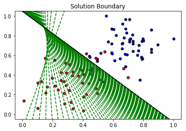

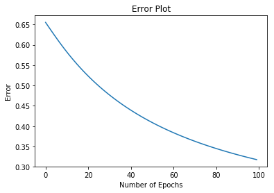

```python
def sigmoid(x):
    return 1 / (1 + np.exp(-x))

def output_formula(features, weights, bias):
    return sigmoid(np.dot(features, weights) + bias)

def error_formula(y, output):
    return -y*np.log(output) - (1-y)*np.log(1-output)

def update_weights(x, y, weights, bias, learn_rate):
    '''
    Gradient Descent Step
    '''
    y_hat = output_formula(x, weights, bias)
    d_err = (y - y_hat)
    weights += learn_rate * d_err * x
    bias += learn_rate * d_err
    return weights, bias

# Gradient descent update: w_i += alpha * (y-y_hat) * x_i
# Perceptron update: w_i += alpha * x_i (if y_hat < y); w_i -= alpha * x_i (if y_hat > y)
# In perceptron setup, y and y_hat can only be 0 or 1, therefore:
# when y_hat<y => y-y_hat=1 => w_i += alpha * (y-y_hat) * x_i
# when y_hat>y => y-y_hat=-1 => w_i -= - alpha * (y-y_hat) * x_i => w_i += alpha * (y-y_hat) * x_i
# Hence the two update algorithms are equivalent


np.random.seed(111)

def trainGradientDescent(features, targets, epochs=100, learn_rate=0.01, graph_lines=False):
    errors = []
    n_records, n_features = features.shape
    weights = np.random.normal(scale=1/n_features**0.5, size=n_features)
    bias = 0

    for e in range(epochs):
        for x, y in zip(features, targets):
            y_hat = output_formula(features, weights, bias)
            error = error_formula(y, y_hat)
            weights, bias = update_weights(x, y, weights, bias, learn_rate)

        # Append loss
        out = output_formula(features, weights, bias)
        loss = np.mean(error_formula(targets, out))
        errors.append(loss)

        # Printing loss & accuracy
        if e % (epochs/10) == 0:
            predictions = out > 0.5
            accuracy = np.mean(predictions == targets)
            print("\nEpoch: ", e, ".... Train Loss: ", loss, ".... Accuracy: ", accuracy)

        if graph_lines and e % (epochs/100) == 0:
            display(-weights[0]/weights[1], -bias/weights[1])

    # Plot solution boundary
    plt.title("Solution Boundary")
    display(-weights[0]/weights[1], -bias/weights[1], 'black')

    # Plot data
    plot_points(features, targets)
    plt.show()

    #Plot Error
    plt.title("Error Plot")
    plt.xlabel("Number of Epochs")
    plt.ylabel("Error")
    plt.plot(errors)
    plt.show()

# Implementation with sample data from the calss
#------------------------------------------------
data1_2 = pd.read_csv(".\\ClassSampleData\\Data1.2.csv", header=None)
X = np.array(data1_2[[0,1]])
y = np.array(data1_2[2])
trainGradientDescent(X, y, 100, 0.01, True)
```

## 1.3 Backpropagation

### 1.3.1 No Hidden Layer

**Mean Square Error** Loss: $E=\frac{1}{2m}*\sum{(y-\hat{y})^2}$

Error Updating Chain-rule: $\partial{E}/\partial{w_i} = - \frac{1}{m} *(y-\hat{y}) * \partial(\hat{y})/\partial{w_i}$  
where $\hat{y}=f(h)$ and $h = \Sigma w_i x_i$

if $f$ is **sigmoid function** then $\partial{\hat{y}}/\partial{w_j} = f'(h) * x_i = \hat{y} * (1-\hat{y}) * x_j$

==> $\partial{E}/\partial{w_i} = - \frac{1}{m} *(y-\hat{y}) * \hat{y} * (1-\hat{y}) * x_j$

1. Set the weight step to zero: $\Delta w_i = 0$
2. For each record in training:  
   2.1 Forward Pass: $\hat{y}=\delta(\Sigma w_i x_i)$  
   2.2 Output Error: $e = y - \hat{y}$  
   2.3 Error Term: $\delta = e * f'(h) = (y - \hat{y}) * \hat{y} * (1-\hat{y})$  
   2.4 Update weight step: $\Delta w_i = \Delta w_i + \delta * x_i$
3. Update weights: $w_i = w_i + \eta * \Delta w_i/ m$
4. repeat for e epochs

```python
def sigmoid_prime(x):
    return sigmoid(x) * (1-sigmoid(x))

def error_term_formula(y, output):
    return (y-output) * output * (1-output)

def train_nn(features, targets, epochs=1000, learn_rate=0.5):
    n_records, n_features = features.shape
    weights = np.random.normal(scale=1/n_features**0.5, size=n_features)

    for e in range(epochs):
        del_w = np.zeros(weights.shape)
        for x, y in zip(features, targets):
            y_hat = sigmoid(np.dot(x, weights))
            error = error_formula(y, y_hat)
            error_term = error_term_formula(y, y_hat)
            del_w += error_term * x
        weights += learn_rate * del_w / n_records

        if e % (epochs/10)==0:
            out = sigmoid(np.dot(features, weights))
            loss = np.mean((out-targets)**2)
            print("Epoch: ", e, ".... Loss: ", loss)
    return weights
```

```python
# Implementation with sample data from the calss
#------------------------------------------------
data1_3 = pd.read_csv(".\\ClassSampleData\\Data1.3_student_data.csv")
#plot_points(np.array(data1_3[['gre','gpa']]), np.array(data1_3['admit']))
# Process data: one hot encoding and scaling
one_hot_data = one_hot_encoding(data1_3, ['rank'])

# one_hot_data['gre'] = one_hot_data['gre']/800
# one_hot_data['gpa'] = one_hot_data['gpa']/4.0
one_hot_data = standadize(one_hot_data, ['gre', 'gpa'])

np.random.seed(21)
Train, Test = train_test_split(one_hot_data, 0.9)
features, targets = feature_target_split(Train, 'admit')
features_test, targets_test = feature_target_split(Test, 'admit')

# Model training
np.random.seed(42)
weights = train_nn(features, targets)

# Check performance
test_out = sigmoid(np.dot(features_test, weights))
test_predictions = test_out > 0.5
test_accuracy = np.mean(test_predictions == targets_test)
print("Test Prediction accuracy: {:.3f}".format(test_accuracy))
```

```
Epoch:  0 .... Loss:  0.2638884022720776
Epoch:  100 .... Loss:  0.20935104583264205
Epoch:  200 .... Loss:  0.20062257227475228
Epoch:  300 .... Loss:  0.19829121025900504
Epoch:  400 .... Loss:  0.1973952753145473
Epoch:  500 .... Loss:  0.19697344063163347
Epoch:  600 .... Loss:  0.1967494566968915
Epoch:  700 .... Loss:  0.1966207882505881
Epoch:  800 .... Loss:  0.19654265039347432
Epoch:  900 .... Loss:  0.19649321947388051
Test Prediction accuracy: 0.750
```

### 1.3.2 One Hidden Layer - MLP

Input layer: $Out_1=X$

Hidden layer: $Out_2=f(Z_2)=f(\Sigma{w_{ih}*Out_1)}=f(\Sigma{w_{ih}*X_i})$  
==> $\partial{Out_2}/\partial{w_{ih}}=Out_2*(1-Out_2)*X$

Output layer: $\hat{y}=Out_3=f(Z_3)=f(\Sigma{w_{ho}*Out_2})$  
==> $\partial{Out_3}/\partial{w_{ho}}=Out_3 * (1-Out_3) * Out_{2h}$

For **Mean Square Error** Loss: $E=\frac{1}{2m}*\sum{(y-\hat{y})^2}$

Error Updating Chain-rule: $\partial{E}/\partial{\hat{y}} = - \frac{1}{m} *(y-\hat{y})$

**Output Layer Weight Update:**  
$\partial{E}/\partial{w_{ho}} = \partial{E}/\partial{\hat{y}} * \partial{\hat{y}}/\partial{w_{ho}} = - \frac{1}{m} *(y-\hat{y}) * Out_3 * (1-Out_3) * Out_{2h} = - \frac{1}{m} *(y-\hat{y}) * \hat{y} * (1-\hat{y}) * Out_{2h}$  
Error: $y-\hat{y}$  
Error Term: $ error * f' = error * \hat{y} * (1-\hat{y})$

**Hidden Layer Weight Update:**  
$\partial{E}/\partial{w_{ih}} = \partial{E}/\partial{\hat{y}} * \partial{\hat{y}}/\partial{Out_2} * \partial{Out_2}/\partial{w_{ih}} = - \frac{1}{m} *(y-\hat{y}) * \hat{y} * (1-\hat{y}) * w_{ho} * Out_2*(1-Out_2)*X$  
Hidden Error: $ Error Term * w_{ho} = error * \hat{y} * (1-\hat{y}) * w_{ho}$  
Hidden Error Term: $ Hidden Error * f' = error * \hat{y} * (1-\hat{y}) * w_{ho} * Out_2*(1-Out_2)$

1. Set weight steps for each layer to 0  
   1.1. Input to hidden: $\Delta w_{ih}$  
   1.2. Hidden to output: $\Delta w_{ho}$
2. For each record in training:  
   2.1. Forward pass: $\hat{y}$  
   2.2. Error for the output units: $\delta^o = (y-\hat{y})f'(Z_2)=(y-\hat{y})f'(\Sigma{w_{ho}*Out_2})=(y-\hat{y})*\hat{y} * (1-\hat{y})$  
   2.3. Probagate to hidden layer units: $\delta^h = \delta^o*w_{ho}*f'(\Sigma{w_{ih}*X_i})=\delta^o*w_{ho}*Out_2*(1-Out_2)$  
   2.4. Update weight steps:  
   $\Delta w_{ho}+=\delta^o*Out_2$  
   $\Delta w_{ih}+=\delta^j*Out_1$
3. Update the weight  
   $w_{ho}+=\eta*\Delta w_{ho} /m$  
   $w_{ih}+=\eta*\Delta w_{ih} /m$
4. Repeat for e epochs

```python
np.random.seed(21)

def trainMLP(features, targets, n_hidden=2, epochs=900, learn_rate=0.005):
    n_records, n_features = features.shape

    # Initialize weights
    weights_input_hidden = np.random.normal(scale=1 / n_features ** .5, size=(n_features, n_hidden))
    weights_hidden_output = np.random.normal(scale=1 / n_features ** .5, size=n_hidden)

    for e in range(epochs):
        del_w_input_hidden = np.zeros(weights_input_hidden.shape)
        del_w_hidden_output = np.zeros(weights_hidden_output.shape)

        for x, y in zip(features, targets):
            ## Forward pass ##
            hidden_input = np.dot(x, weights_input_hidden)
            hidden_output = sigmoid(hidden_input)

            output = sigmoid(np.dot(weights_hidden_output, hidden_output))

            ## Backward pass ##
            error = y - output
            output_error_term = error * output * (1 - output)

            ## propagate errors to hidden layer
            hidden_error = np.dot(weights_hidden_output, output_error_term)
            hidden_error_term = hidden_error * hidden_output * (1 - hidden_output)

            #Update the change in weights
            del_w_hidden_output += output_error_term * hidden_output
            del_w_input_hidden += hidden_error_term * x[:, None]

        #Update weights
        weights_input_hidden += learn_rate * del_w_input_hidden / n_records
        weights_hidden_output += learn_rate * del_w_hidden_output / n_records

        # Printing out the mean square error on the training set
        if e % (epochs / 10) == 0:
            hidden_output = sigmoid(np.dot(x, weights_input_hidden))
            out = sigmoid(np.dot(hidden_output, weights_hidden_output))
            loss = np.mean((out - targets) ** 2)

            print("Train loss: ", loss)

    return weights_input_hidden, weights_hidden_output

weights_input_hidden, weights_hidden_output = trainMLP(features, targets)

# Calculate accuracy on test data
hidden = sigmoid(np.dot(features_test, weights_input_hidden))
out = sigmoid(np.dot(hidden, weights_hidden_output))
predictions = out > 0.5
accuracy = np.mean(predictions == targets_test)
print("Prediction accuracy: {:.3f}".format(accuracy))
```

```
Train loss:  0.2513572524259881
Train loss:  0.24996540718842905
Train loss:  0.24862005218904504
Train loss:  0.2473199321717981
Train loss:  0.24606380465584854
Train loss:  0.24485044179257037
Train loss:  0.243678632018683
Train loss:  0.24254718151769472
Train loss:  0.24145491550165454
Train loss:  0.24040067932493334
Prediction accuracy: 0.725
```

## 1.4 First Neural Network

```python
class NeuralNetwork(object):
    '''
    hidden layer activation: f=sigmoid
    output layer activation: f=x
    '''
    def __init__(self, input_nodes, hidden_nodes, output_nodes, learning_rate):
        self.input_nodes = input_nodes
        self.hidden_nodes = hidden_nodes
        self.output_nodes = output_nodes
        self.lr = learning_rate

        self.w_input_to_hidden = np.random.normal(0.0, self.input_nodes**-0.5, (self.input_nodes, self.hidden_nodes))
        self.w_hidden_to_output = np.random.normal(0.0, self.hidden_nodes**-0.5, (self.hidden_nodes, self.output_nodes))

        self.activation_function = lambda x : 1/(1+np.exp(-x))

    def forward_pass(self, X):
        hidden_in = np.dot(X, self.w_input_to_hidden)
        hidden_out = self.activation_function(hidden_in)

        output_in = np.dot(hidden_out, self.w_hidden_to_output)
        output_out = output_in

        return output_out, hidden_out

    def backpropagation(self, output_out, hidden_out, X, y, del_w_i_h, del_w_h_o):
        error = y - output_out
        out_error_term = error * 1

        hidden_error = np.dot(self.w_hidden_to_output, out_error_term)
        hidden_error_term = hidden_error * hidden_out * (1-hidden_out)

        del_w_i_h += hidden_error_term * X[:,None]
        del_w_h_o += out_error_term * hidden_out[:,None]

        return del_w_i_h, del_w_h_o

    def update_weights(self, del_w_i_h, del_w_h_o, n_records):
        self.w_hidden_to_output += self.lr * del_w_h_o /n_records
        self.w_input_to_hidden += self.lr * del_w_i_h /n_records

    def train(self, features, targets):
        n_records = features.shape[0]
        del_w_i_h = np.zeros(self.w_input_to_hidden.shape)
        del_w_h_o = np.zeros(self.w_hidden_to_output.shape)

        for X, y in zip(features, targets):
            output_out, hidden_out = self.forward_pass(X)
            del_w_i_h, del_w_h_o = self.backpropagation(output_out, hidden_out, X, y, del_w_i_h, del_w_h_o)
            self.update_weights(del_w_i_h, del_w_h_o, n_records)

    def run(self, features):
        hidden_in = np.dot(features, self.w_input_to_hidden)
        hidden_out = self.activation_function(hidden_in)

        output_in = np.dot(hidden_out, self.w_hidden_to_output)
        output_out = output_in

        return output_out
```

```python
# Implementation with sample data from the calss
#------------------------------------------------
data1_4 = pd.read_csv(".\\ClassSampleData\\Data1.4_bike_hour.csv")
data = one_hot_encoding(data1_4, ['season', 'weathersit', 'mnth', 'hr', 'weekday'])
data = data.drop(['instant', 'dteday', 'atemp', 'workingday'], axis=1)

data = standadize(data, ['casual', 'registered', 'cnt', 'temp', 'hum', 'windspeed'])

# Split train, test, val
train, test = data[:-21*24], data[-21*24:]
train, val = train[:-60*24], train[-60*24:]

# Separate the data into features and targets
target_fields = ['cnt', 'casual', 'registered']
train_features, train_targets = train.drop(target_fields, axis=1), train[target_fields]
val_features, val_targets = val.drop(target_fields, axis=1), val[target_fields]
test_features, test_targets = test.drop(target_fields, axis=1), test[target_fields]
```

```
iteration:  0 ....train loss:  1.1985302659789117 ....validation loss:  1.9874905159008391
iteration:  200 ....train loss:  0.13810289498877903 ....validation loss:  0.26692114320295346
iteration:  400 ....train loss:  0.14309113667762552 ....validation loss:  0.24819623148023276
iteration:  600 ....train loss:  0.3207285548743962 ....validation loss:  0.4874338544613443
iteration:  800 ....train loss:  0.15771573168627825 ....validation loss:  0.1905259799148019
iteration:  1000 ....train loss:  0.11387057535670093 ....validation loss:  0.1688385299470304
iteration:  1200 ....train loss:  0.10288280767449823 ....validation loss:  0.19177600591107866
iteration:  1400 ....train loss:  0.10541627119347553 ....validation loss:  0.22894095791414604
iteration:  1600 ....train loss:  0.17426243475652212 ....validation loss:  0.44723948155528953
iteration:  1800 ....train loss:  0.06136486813928894 ....validation loss:  0.14084658300938882
```

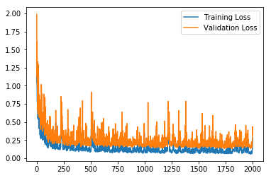

```python
# Train the model
network = NeuralNetwork(train_features.shape[1], 18, 1, 0.5)
iteration = 2000

losses = {'train':[], 'validation':[]}
for i in range(iteration):
    batch = np.random.choice(train_features.index, size=128)
    X, y = train_features.iloc[batch].values, train_targets.iloc[batch]['cnt']

    network.train(X, y)

    train_loss = MSE(network.run(train_features).T, train_targets['cnt'].values)
    val_loss = MSE(network.run(val_features).T, val_targets['cnt'].values)

    if i % (iteration/10)==0:
        print('iteration: ', i, '....train loss: ', train_loss, '....validation loss: ', val_loss)

    losses['train'].append(train_loss)
    losses['validation'].append(val_loss)

plt.plot(losses['train'], label="Training Loss")
plt.plot(losses['validation'], label="Validation Loss")
plt.legend()
_=plt.ylim()
```

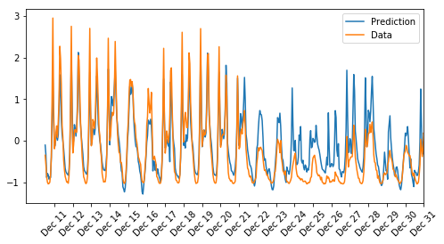

```python
#Check Prediction on Testing datasets
fig, ax = plt.subplots(figsize=(8,4))

mean, std = data['cnt'].mean(), data['cnt'].std()
predictions = network.run(test_features).T*std + mean
ax.plot(predictions[0], label='Prediction')
ax.plot((test_targets['cnt']*std + mean).values, label='Data')
ax.set_xlim(right=len(predictions))
ax.legend()

dates = pd.to_datetime(data1_4.iloc[test.index]['dteday'])
dates = dates.apply(lambda d: d.strftime('%b %d'))
ax.set_xticks(np.arange(len(dates))[12::24])
_ = ax.set_xticklabels(dates[12::24], rotation=45)
```